# Project on Racial Composition - Insurance Policy

Adhiraj Mandal  
Bhargob Kakoty  
Pritam Dey

# **DATA**

### Data on racial composition, income and age and value of residential units for each ZIP code in Chicago

In a study of insurance availability in Chicago, the U.S. Commission on Civil Rights attempted to examine charges by several community organizations that insurance companies were redlining their neighborhoods, ie. cancelling policies or refusing to insure or renew. Most FAIR plan policyholders secure such coverage only after they have been rejected by the voluntary market, rather than as a result of a preference for that type of insurance, the distribution of FAIR plan policies is another measure of insurance availability in the voluntary market.

The first few rows of our data is given below:

| …1 | race | fire | theft | age | volact | involact | income |
| --- | --- | --- | --- | --- | --- | --- | --- |
| 60626 | 10.0 | 6.2 | 29 | 60.4 | 5.3 | 0.0 | 11744 |
| 60640 | 22.2 | 9.5 | 44 | 76.5 | 3.1 | 0.1 | 9323 |
| 60613 | 19.6 | 10.5 | 36 | 73.5 | 4.8 | 1.2 | 9948 |
| 60657 | 17.3 | 7.7 | 37 | 66.9 | 5.7 | 0.5 | 10656 |
| 60614 | 24.5 | 8.6 | 53 | 81.4 | 5.9 | 0.7 | 9730 |
| 60610 | 54.0 | 34.1 | 68 | 52.6 | 4.0 | 0.3 | 8231 |

# DESCRIPTION

**race** : racial composition in percent minority

**fire** : fire incidents per 100 housing units

**theft** : theft per 1000 population

**age** : percent of housing units built before 1939

**volact** : new homeowner policies plus renewals minus cancellations and non renewals per 100 housing units

**involact**: new FAIR plan policies and renewals per 100 housing units

**income** : median family income

# **ANALYSIS OF THE PROBLEM**

Homeowner’s insurance is a form of property insurance that covers losses and damages to an individual’s house and to assets in the home. Homeowner’s insurance also provides liability coverage against incidents in the home or on the property.  
These policies might get rejected under various circumstances, such as,

- If the building is very old.(High values in the **age** column)
- If the building is prone to catch fire. (High values in the **fire** column)
- If the locality is prone to theft incidents. (High values in the **theft** column)

The **volact** column represents the net increase in the number of homeowner policies in different ZIP Codes. If the claim of the Community organizations is true, the percentage minority of a particular race in a region should impact the **volact** negatively. We would like to check if the other factors such as **age, fire, theft, income** depend on **volact**. The **involact** column which gives the number of FAIR plan policies (both new and renewal) can only reveals the number of rejected homwowner policies, but fails to give any information regarding the new policies. Therefore **volact** appears as the best candidate for response variable.

# **OBJECTIVE**

To carry out a Statistical test to investigate if the claim of the Community Organizations is valid.  
The **Null Hypothesis** is that there is no significant impact of the race in availing policy from the voluntary market, against the **Alternative Hypothesis** that there is a negative impact of the race in availing the same.

# **GRAPHICAL REPRESENTATION OF THE DATA**

Before going into the analysis, we try to have some overall idea about the data by looking at the **Scatterplot**.

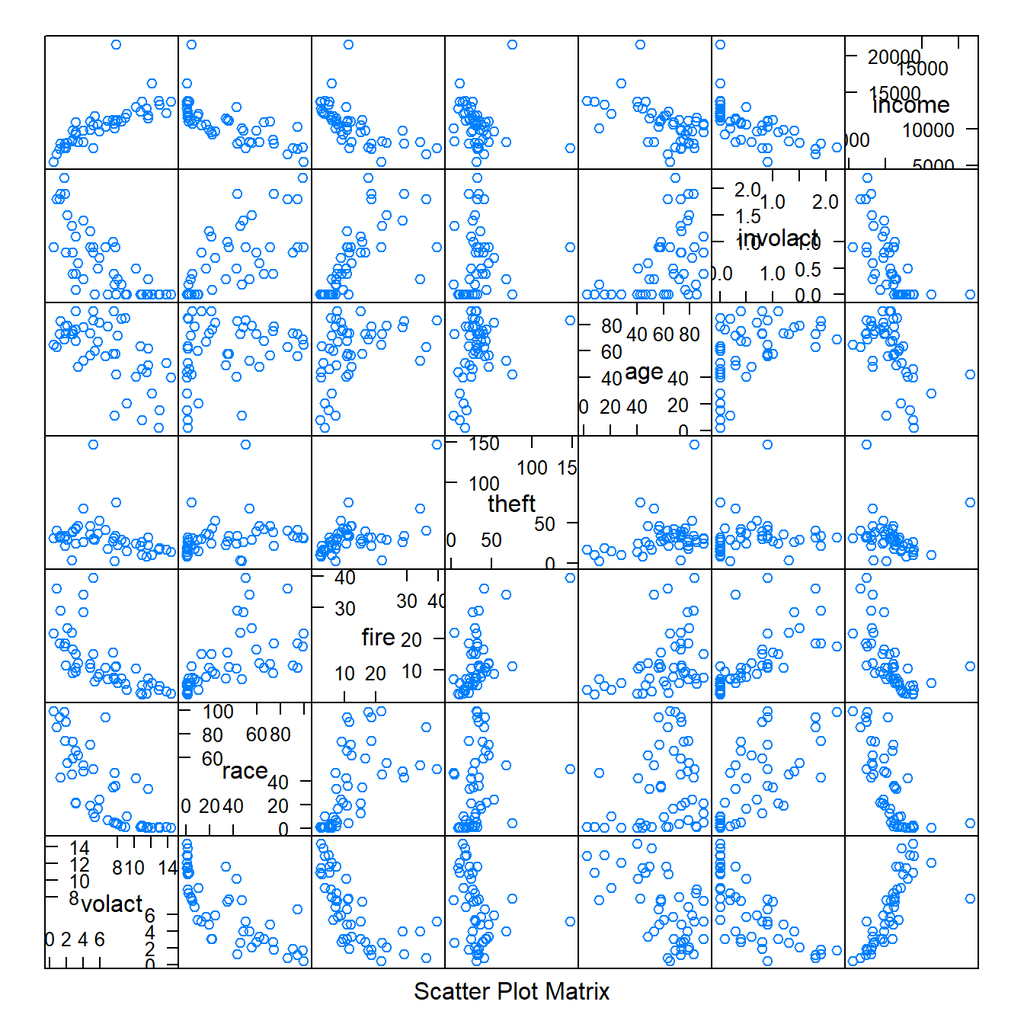

# **GRAPHICAL REPRESENTATION OF THE DATA (continued)**

- From the Scatter Plot Matrix, it can be seen that **theft** has no visible relationships with the other variables.
- Apparently **Volact** is *negatively* related with all other variables except **income** and **theft**.It has a strong *positive* relationship with **income**.
- **Involact** shows exactly the opposite picure of **volact**.
- There is a positive relationship between **race** and **fire**.
- **fire** has a slight positive relationship with **age**. It clearly incdicates that as the houses get old, the chance of catching fire incidents increases.
- **income** shows a linear relationship with every other variable except for **theft**.

# **SELECTION OF APPROPRIATE MODEL**

We shall try to fit various linear models to the given data set by taking *volact* as response variable and selecting different subsets of explanatory variables from *race*, *age*, *fire*, *theft*, *income*, *involact*. The ultimate model selection will be based on some popularly used criteria such as *Residual Sum of Squares (RSS), Adjusted $R^2$, Akaike Information Criterion (AIC)* and *Mallow’s CP*. Since the scatter plot shows relationships between most pairs of variables, we will also consider **condition number($\kappa$)** as one of the model selection criteria.

We shall investigate the measures of all such criteria for all possible subsets ($2^6 - 1 = 63$) of these explanatory variables. Then we will sort different models based on **adjusted $R^2$** and choose such a model that has lower values of **AIC** and **kappa**.

# **SELECTING APPROPIATE SUBSET**

| predictors | adjr | cp | aic | bic | kappa |
| --- | --- | --- | --- | --- | --- |
| race age fire theft | 0.7719758 | 3.541960 | 200.1342 | 68.29620 | 8.546039 |
| race age fire | 0.7707816 | 2.724635 | 199.4857 | 67.08496 | 7.657315 |
| race age fire income | 0.7704256 | 3.817591 | 200.4527 | 68.54124 | 24.802400 |
| race age fire income theft | 0.7687606 | 5.134724 | 201.6597 | 70.27367 | 28.217151 |
| race age fire involact | 0.7687154 | 4.121664 | 200.8015 | 68.80994 | 9.289235 |
| race age fire income involact | 0.7678592 | 5.291182 | 201.8426 | 70.40504 | 26.859473 |

# **SELECTING APPROPIATE SUBSET (continued)**

If $Y$ denote the values of the response variable **volact**, the considered model is given below:-

$$\begin{equation*}
Y=\beta_0+\beta_1X_{1}+\beta_2 X_{2}+\beta_3 X_{3}+ \epsilon
\end{equation*}$$

Here $X_1,X_2,X_3$ denote the values corresponding to the columns *race, age, fire* respectively and, we assume that, $\epsilon$ has the following properties :

- it has 0 expectation
- variance covariance matrix of $\epsilon$ is $\sigma^2I_n$
- It is normally distributed

# DETECTION OF OUTLIERS

We will try to detect influential points in our model with the help of *Cook’s D Bar Plot* and *DFFIT plot*.

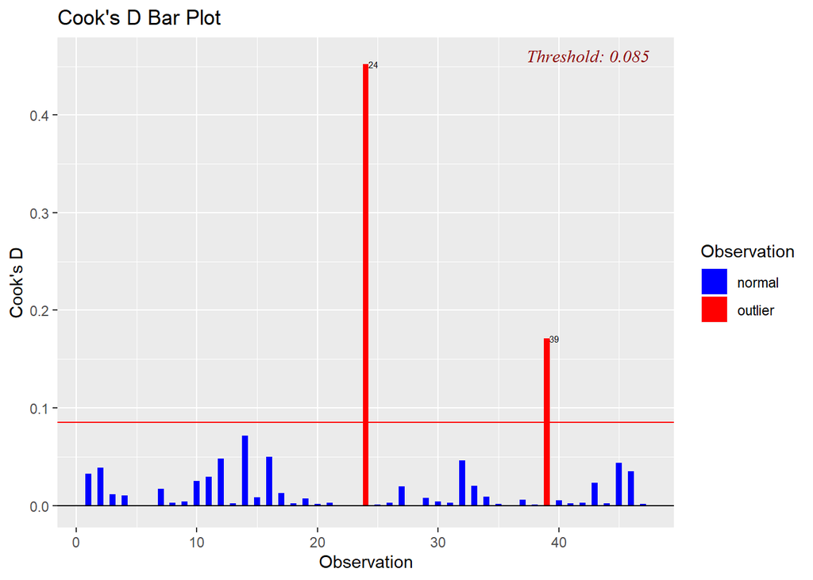

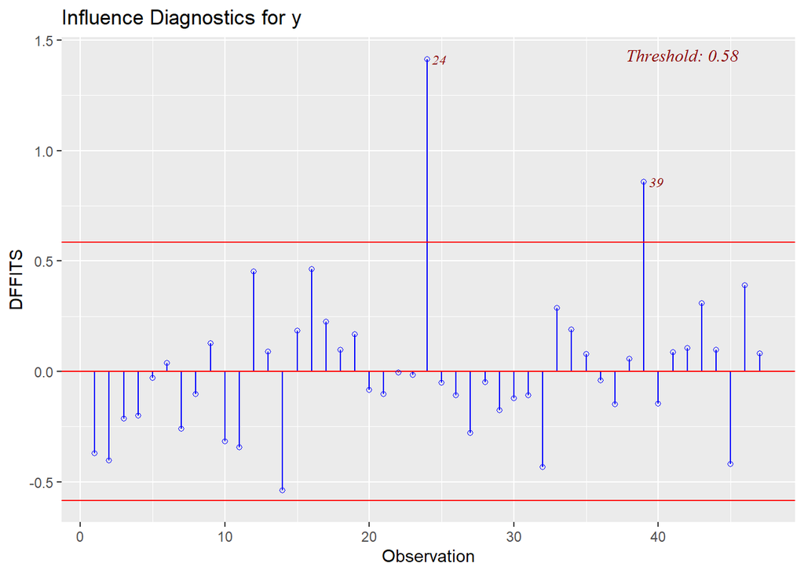

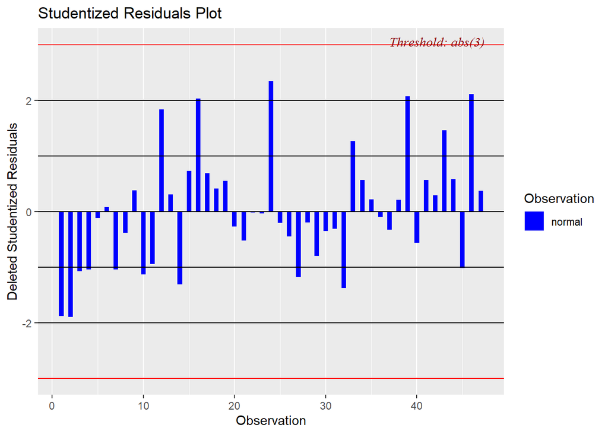

# **DETECTION OF OUTLIERS (continued)**

These are the values for the original model

adjusted $R^2$: 0.7707816

$\hat\sigma^2$: 3.606295

# **DETECTION OF OUTLIERS (continued)**

Here are the values after removing outliers

adjusted $R^2$: 0.8135019

$\hat\sigma^2$: 3.059881

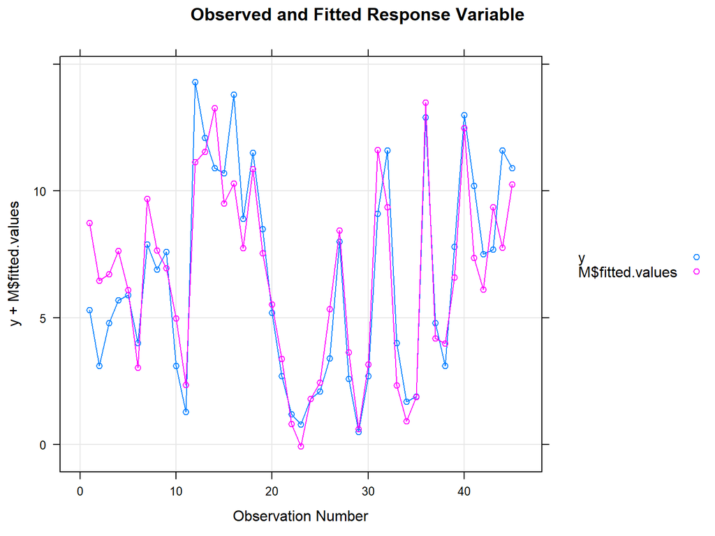

We can see from the *Observed vs Fitted* plot that the fit is pretty good. The $\hat\sigma^2$ and adjusted $R^2$ values have also improved. Next we will like to check the normality and homoscadasticity assumptions for our model.

# **CHECKING FOR ASSUMPTIONS**

## NORMALITY:

The normal qqplot of the model after removal of the outliers is presented below

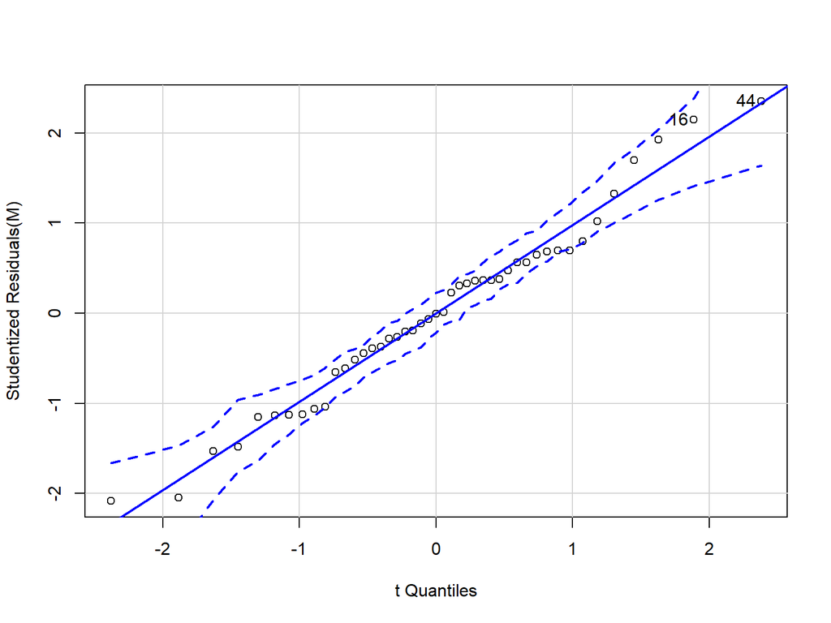

# **CHECKING FOR NORMALITY (continued)**

From the qqplot it can be observed that almost all the points are within the 95% confidence band, but still we will perform **Shapiro-Wilk test** for normality to have a better idea.

```
##
##  Shapiro-Wilk normality test
##
## data:  y
## W = 0.98026, p-value = 0.6301
```

It shows that we do not have any strong evidence for rejecting the null hypothesis that the errors are normally distributed.

# CHECKING FOR HOMOSCEDASTICITY:

We will perform *Breusch-Pagan* test to check for homoscedasticity. The p-value for this test statistic is given below.

```
##
##  Breusch Pagan Test for Heteroskedasticity
##  -----------------------------------------
##  Ho: the variance is constant
##  Ha: the variance is not constant
##
##             Data
##  -----------------------------
##  Response : y
##  Variables: fitted values of y
##
##         Test Summary
##  -----------------------------
##  DF            =    1
##  Chi2          =    4.960035
##  Prob > Chi2   =    0.02593968
```

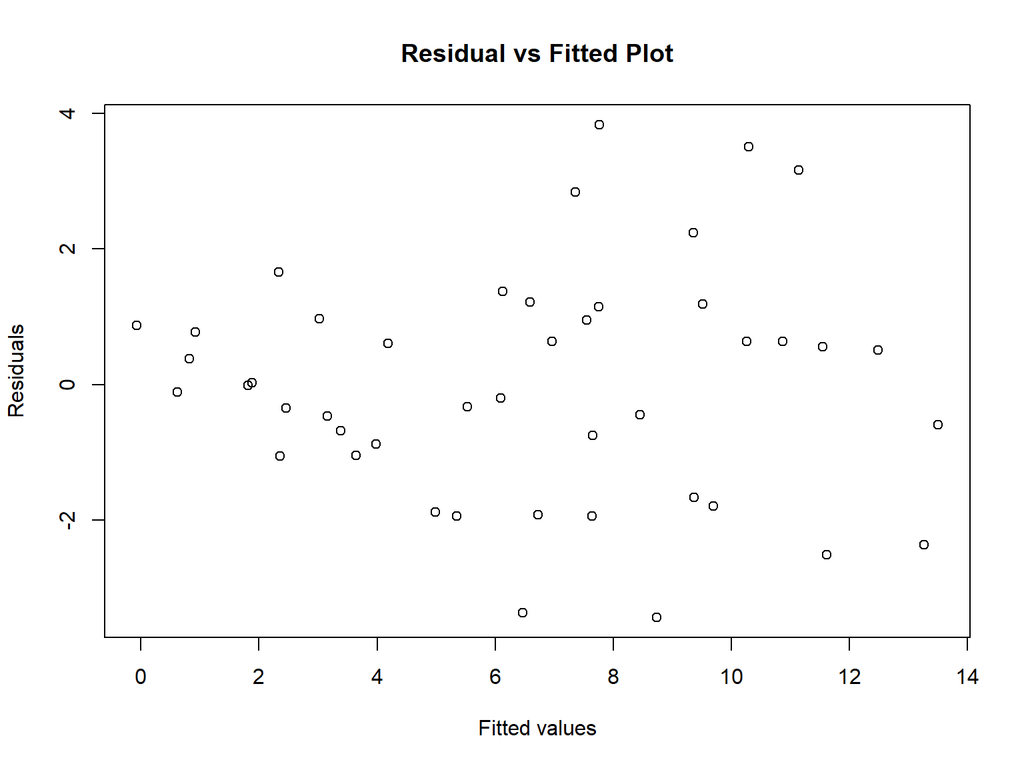

# APPLYING TRANSFORMATIONS

Now, we are going to make various transformations on the response variable, to make the data homoscedastic. We will try a series of transformations using the *trafo* package in *R*. We will select that transformation which gives the lowest value of $\hat\sigma^2$.

The different transformations used in this project are listed below

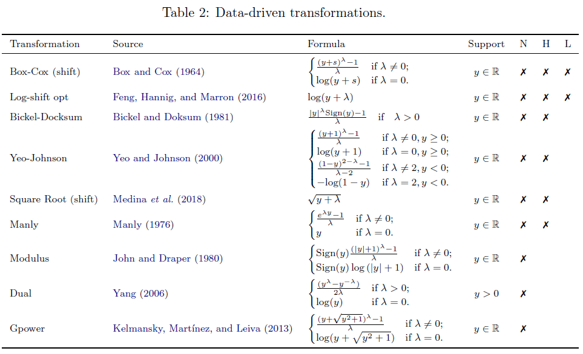

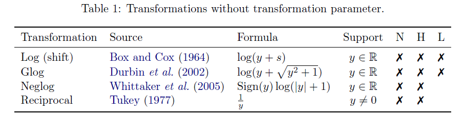

# RESULTS OF THE TRANSFORMATIONS

| transf | $\hat\sigma^2$ | adjusted $R^2$ |
| --- | --- | --- |
| boxcox | 0.392533983400502 | 0.844690804896685 |
| bickeldoksum | 0.392542263660149 | 0.84469073599327 |
| logshiftopt | 0.0322775273743844 | 0.845775593107643 |
| yeojohnson | 0.193158702455696 | 0.845128277358805 |
| sqrtshift | 0.102309110555102 | 0.842665331030252 |
| manly | 0.862633918402704 | 0.841536277834518 |
| modulus | 0.193158702454934 | 0.845128277358819 |
| dual | 0.301305212779837 | 0.840926657790193 |
| gpower | 0.482662677877516 | 0.845529147090464 |
| log | 0.122766241167932 | 0.819631633760822 |
| glog | 0.0956508240768469 | 0.835858386257998 |
| neglog | 0.0626816745949788 | 0.842286764937687 |
| reciprocal | 0.0598542147478041 | 0.519946364857671 |

# MODEL WITH THE TRANSFORMED VARIABLE

The value of lambda which is estimated using maximum likelihood method has been extracted from *R* and shown below

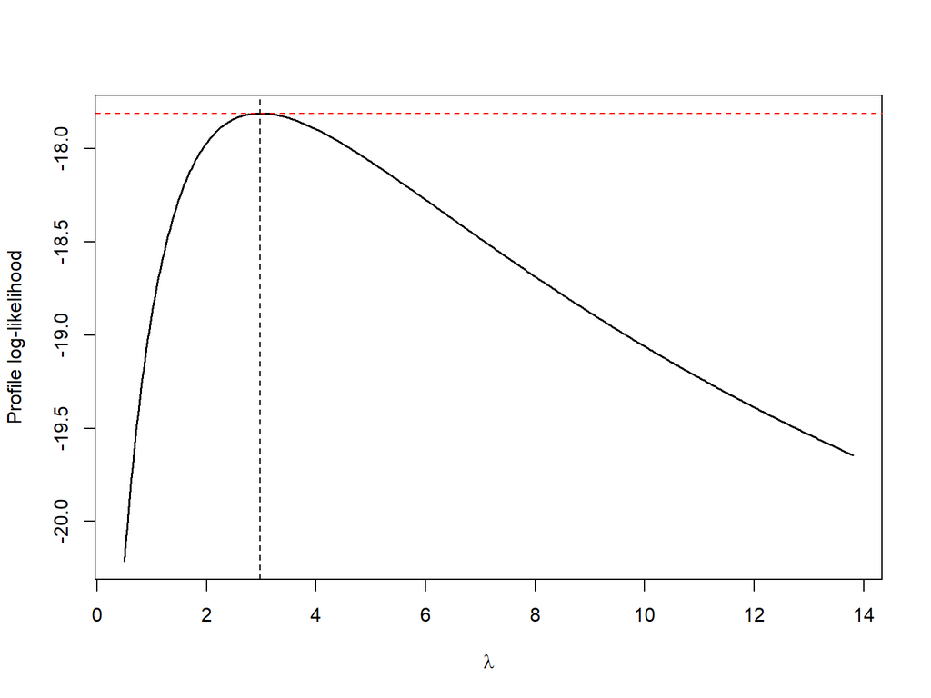

```
## [1] "lambda_hat ->  2.98380544833067"
```

# TRANSFORMED MODEL

Thus, after the transformation our model will be as follows:-
$$\begin{equation*}
Y^{\star}=\beta_0+\beta_1X_{1}+\beta_2X_{2}+\beta_3X_{3}+ \epsilon
\end{equation*}$$

# TESTING FOR NORMALITY

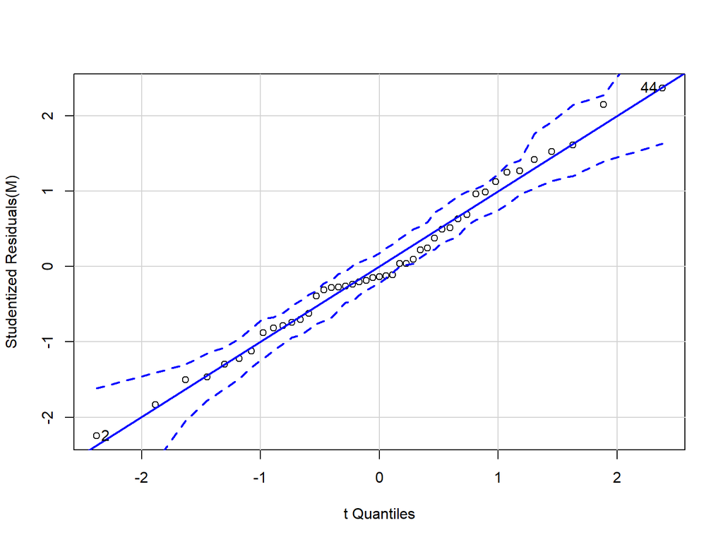

```
##
##  Shapiro-Wilk normality test
##
## data:  y
## W = 0.98577, p-value = 0.8475
```

Neither the plot nor the p-value of the test statistic give strong evidence to reject the null hypothesis of normality. Next we will check for homoscedasticity.

# TESTING FOR HETEROSCEDASTICITY

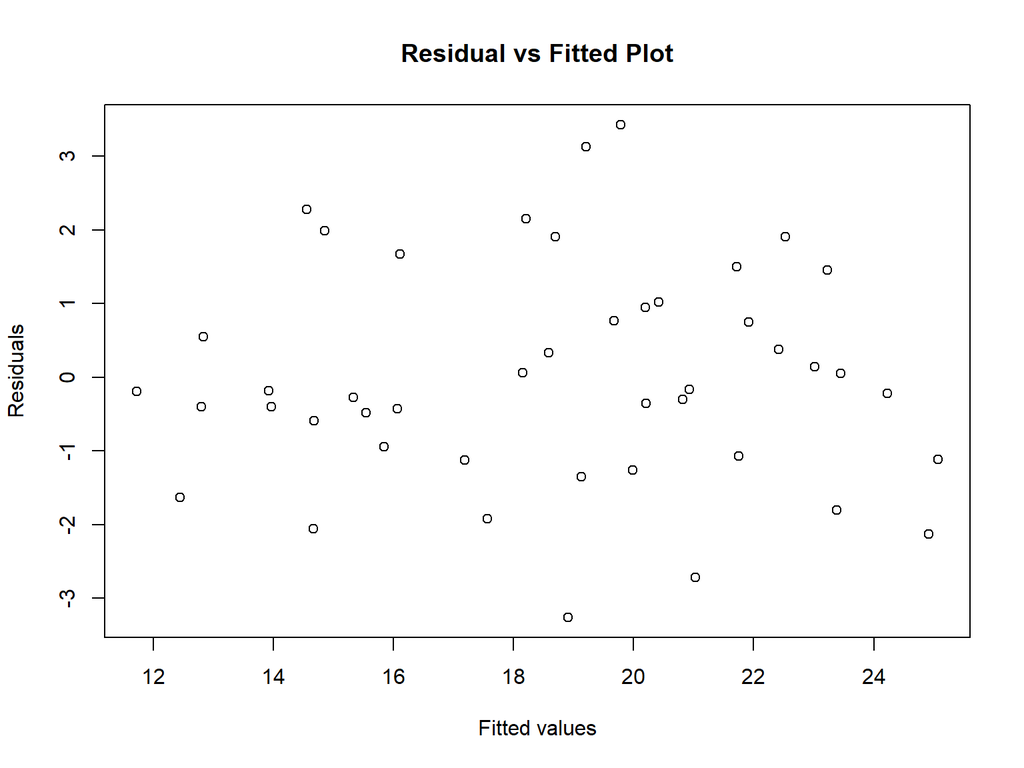

```
##
##  Breusch Pagan Test for Heteroskedasticity
##  -----------------------------------------
##  Ho: the variance is constant
##  Ha: the variance is not constant
##
##                Data
##  ----------------------------------
##  Response : y_star
##  Variables: fitted values of y_star
##
##         Test Summary
##  ----------------------------
##  DF            =    1
##  Chi2          =    0.2277682
##  Prob > Chi2   =    0.6331837
```

Now it can be seen that this transformation has reduced the heteroscedasticity in our data.

# TESTING FOR COLLINEARITY IN OUR TRANSFORMED MODEL:

Firstly we present the scatter plot matrix of our transformed variable against all the explanatory variables.

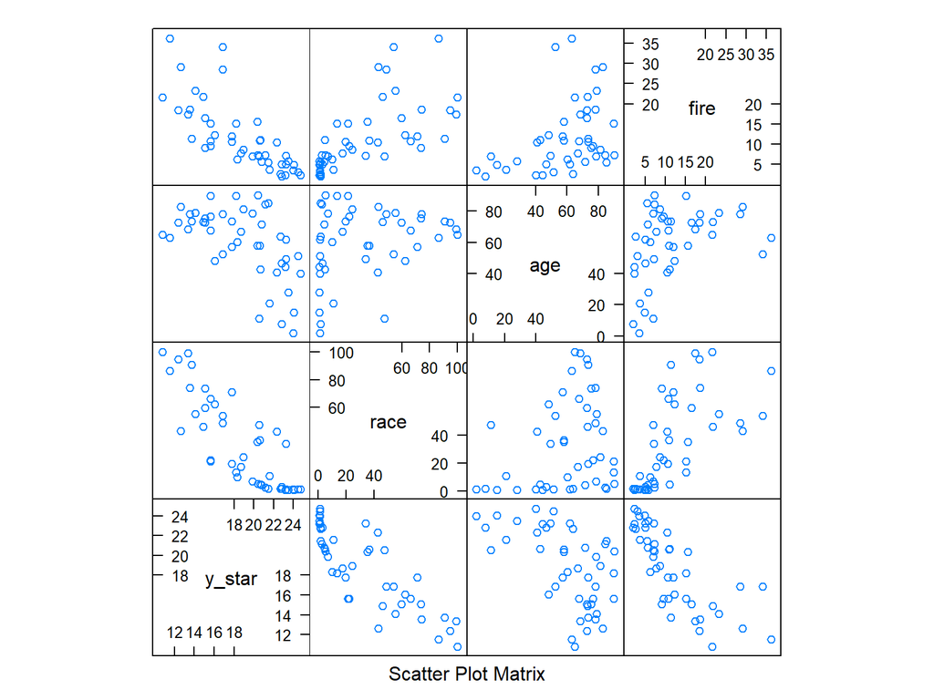

```
## [1] "condition number ->  7.47483697130222"
```

```
## [1] "VIF"
```

```
##     race      age     fire
## 1.764425 1.179141 1.939215
```

Both $\kappa$ and *vif* values are sufficiently lower than their respective cut off points(30 and 5 respectively). So there is no indication of severe multi collinearity in our data.

# SUMMARY OF THE TRANSFORMED MODEL

```
##
## Call:
## lm(formula = y_star ~ race + age + fire, data = data[-c(24, 39),
##     ])
##
## Residuals:
##     Min      1Q  Median      3Q     Max
## -3.2616 -1.0681 -0.1921  0.9459  3.4301
##
## Coefficients:
##              Estimate Std. Error t value Pr(>|t|)
## (Intercept) 25.693009   0.665591  38.602  < 2e-16 ***
## race        -0.071998   0.009745  -7.388 4.69e-09 ***
## age         -0.052614   0.011167  -4.712 2.82e-05 ***
## fire        -0.122859   0.038246  -3.212  0.00256 **
## ---
## Signif. codes:  0 '***' 0.001 '**' 0.01 '*' 0.05 '.' 0.1 ' ' 1
##
## Residual standard error: 1.556 on 41 degrees of freedom
## Multiple R-squared:  0.8563, Adjusted R-squared:  0.8458
## F-statistic: 81.43 on 3 and 41 DF,  p-value: < 2.2e-16
```

We have seen that all the coefficients are significant and the p-value of the $F$ statistic is very low. The adjusted $R^2$ value is pretty satisfactory. Now we will make a partial residual plot in order to check for possible curvature in the explanatory variables.

# PARTIAL RESIDUAL PLOT

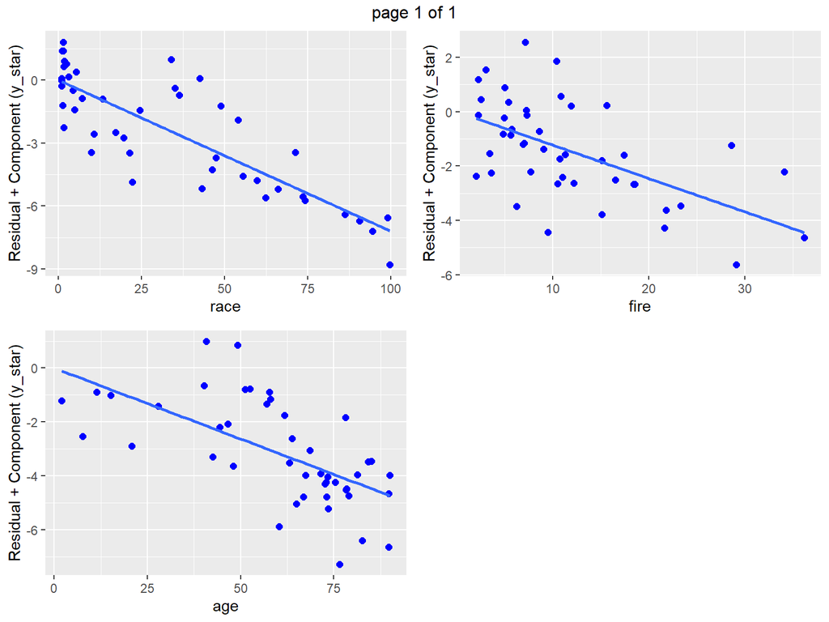

# OBSERVED VS PREDICTED

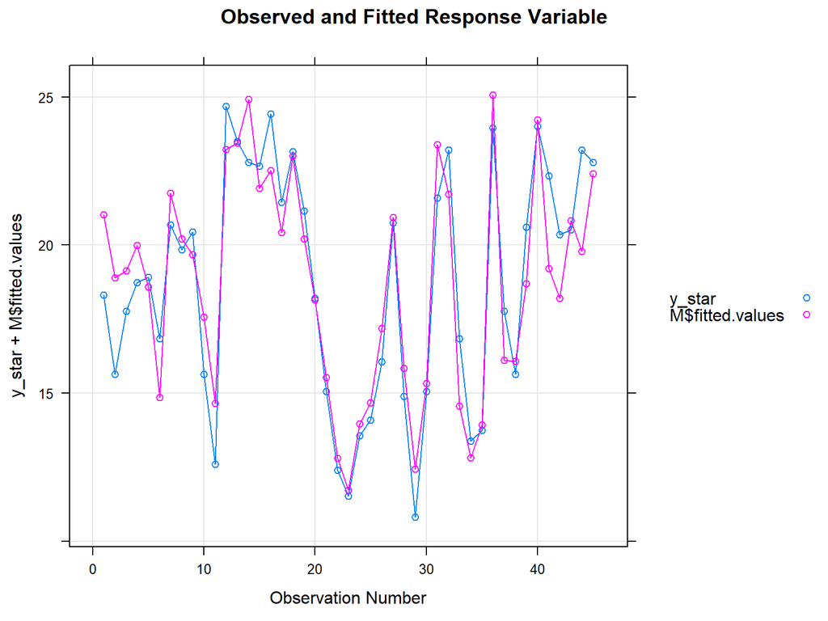

# CONCLUSION:

We can clearly see from the summary that coefficient of race is significant(p-value: 4.69e-09) for predicting volact. We note that the coefficient is negative, hence race has a negative impact over volact. So the claim of the organisation that insurance companies are redlining neighbourhood of this particular race is correct. We also note that the areas having old houses and the areas more prone to fire incidents are getting redlined by different insurance companies in Chicago.